# 17. Seasonal forcing in an open population: R_t around the endemic attractor

ReproductiveNumbers.jl vignettes

Author

Simon D. W. Frost

Published

September 18, 2026

## Overview

In a closed population a single epidemic burns through the susceptibles and `R_t` falls below one for good. With births and deaths the susceptible pool is replenished, the infection persists, and a seasonally varying transmission rate `β(t)` drives recurrent epidemics on an endemic attractor. There `R_t` oscillates *around one*: the phases in which `R_t > 1` are the growing parts of each seasonal epidemic and the phases with `R_t < 1` the declining parts, while the annual average is close to one because susceptibles are consumed and replaced at the same long-run rate.

The model and parameter values follow the forced SIR chapter of the [Epidemiological Recipes cookbook](https://epirecip.es/epicookbook/chapters/sirforced/r): a 70-year life expectancy, a one-week infectious period, an annual sinusoidal forcing of amplitude 5 %, and a population of 100 000. Time is measured in days.

There is no infection-free *steady* state when `β` varies in time, so `R₀` of the forced model is not defined through this package’s construction (seasonally forced models have their own `R₀`, defined through a linear operator on periodic functions, Bacaër and Guernaoui 2006). The effective reproduction number is defined at every instant.

## The model

```julia
using ReproductiveNumbers, ModelingToolkit, Symbolics, OrdinaryDiffEqTsit5, Plots, Statistics
using ModelingToolkit: t_nounits as t, D_nounits as D

@parameters β₀ β₁ ω γ μ N
@variables S(t) I(t) R(t)
β = β₀ * (1 + β₁ * sin(ω * t))
sir = complete(System([D(S) ~ μ * N - β * S * I / N - μ * S,
                       D(I) ~ β * S * I / N - (γ + μ) * I,
                       D(R) ~ γ * I - μ * R], t; name = :forced_sir))
```

```
Model forced_sir:
Equations (3):
  3 standard: see equations(forced_sir)
Unknowns (3): see unknowns(forced_sir)
  S(t)
  I(t)
  R(t)
Parameters (6): see parameters(forced_sir)
  N
  μ
  β₀
  ω
  ⋮
```

For reference, the unforced model (`β₁ = 0`) has a unique infection-free steady state and

```julia
unforced = complete(System([D(S) ~ μ * N - β₀ * S * I / N - μ * S,
                            D(I) ~ β₀ * S * I / N - (γ + μ) * I,
                            D(R) ~ γ * I - μ * R], t; name = :sir))
R0 = basic_reproduction_number(unforced, [I])
```

```
β₀ / (γ + μ)
```

```julia
p = [β₀ => 10 / 7, β₁ => 0.05, ω => 2π / 365, γ => 1 / 7, μ => 1 / (70 * 365), N => 1e5]
ReproductiveNumbers.to_number(substitute(R0, Dict(p)))
```

```
9.997261024376884
```

## R_t as a function of time and state

```julia
Rt = effective_reproduction_number(sir, [I])
```

```
(S(t)*(1 + sin(t*ω)*β₁)*β₀) / (N*(γ + μ))
```

`R_t` is the product of the seasonal factor and the susceptible fraction, scaled by the mean infectious period. We add it to the system as an observed variable, spin the model up for 100 years to reach the attractor, and then follow it for ten years at daily resolution.

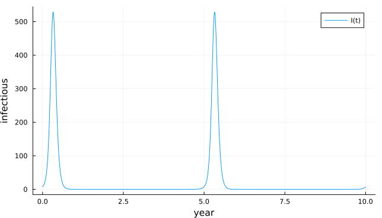

```julia
sir_Rt, Rtvar = add_effective_reproduction_number(sir, [I])
u0 = [S => 99_999.0, I => 1.0, R => 0.0]
year = 365.0
spinup = solve(ODEProblem(sir_Rt, [u0; p], (0.0, 100year)), Tsit5(); save_everystep = false)
# the state on the attractor, by name (compiled systems may order unknowns differently)
attractor = [S => spinup[S][end], I => spinup[I][end], R => spinup[R][end]]
sol = solve(ODEProblem(sir_Rt, [attractor; p], (0.0, 10year)), Tsit5(); saveat = 1.0)
years = sol.t ./ year
plt = plot(years, sol[I]; label = "I(t)", xlabel = "year", ylabel = "infectious", legend = :topright)
```

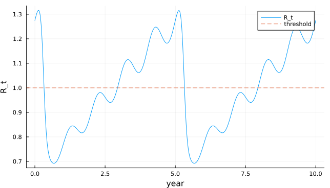

```julia
plt2 = plot(years, sol[Rtvar]; label = "R_t", xlabel = "year", ylabel = "R_t", legend = :topright)
hline!(plt2, [1.0]; label = "threshold", linestyle = :dash)
```

## Reading the two curves together

`R_t` leads prevalence: infections grow exactly while `R_t > 1` and peak when `R_t` crosses one from above. Its annual mean is close to one, which is what an endemic attractor means:

```julia
(mean = mean(sol[Rtvar]), minimum = minimum(sol[Rtvar]), maximum = maximum(sol[Rtvar]))
```

```
(mean = 1.0005471158724972, minimum = 0.6924071936616527, maximum = 1.3158848754752634)
```

The fraction of the population susceptible hovers around `1/R₀`, the endemic level of the unforced model:

```julia
(mean(sol[S]) / 1e5, 1 / ReproductiveNumbers.to_number(substitute(R0, Dict(p))))
```

```
(0.10005040579768684, 0.10002739726027396)
```

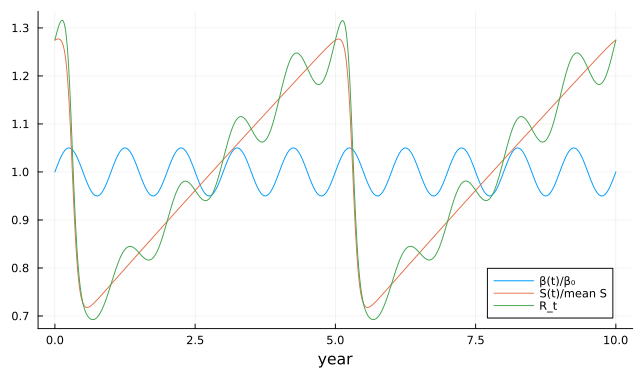

```julia
seasonal = [1 + 0.05 * sin(2π * τ / 365) for τ in sol.t]
plot(years, seasonal; label = "β(t)/β₀", xlabel = "year")
plot!(years, sol[S] ./ mean(sol[S]); label = "S(t)/mean S")
plot!(years, sol[Rtvar]; label = "R_t")
```

## An intervention on the attractor

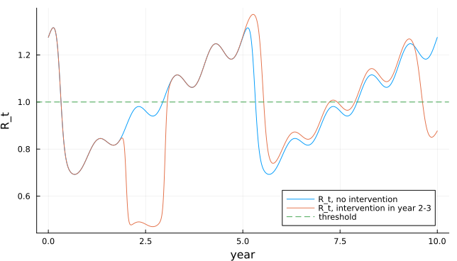

```julia
@parameters c t₁ t₂ k
switch(τ) = 1 / (1 + exp(-k * (τ - t₁))) * (1 - 1 / (1 + exp(-k * (τ - t₂))))
β_int = β * (1 - c * switch(t))
sir_int = complete(System([D(S) ~ μ * N - β_int * S * I / N - μ * S,
                           D(I) ~ β_int * S * I / N - (γ + μ) * I,
                           D(R) ~ γ * I - μ * R], t; name = :forced_sir_intervention))
sir_int_Rt, Rtvar_int = add_effective_reproduction_number(sir_int, [I])
p_int = [p; c => 0.5; t₁ => 2year; t₂ => 3year; k => 0.1]
sol_int = solve(ODEProblem(sir_int_Rt, [attractor; p_int], (0.0, 10year)), Tsit5(); saveat = 1.0)
plt3 = plot(years, sol[Rtvar]; label = "R_t, no intervention", xlabel = "year", ylabel = "R_t")
plot!(plt3, years, sol_int[Rtvar_int]; label = "R_t, intervention in year 2-3")
hline!(plt3, [1.0]; label = "threshold", linestyle = :dash)
```

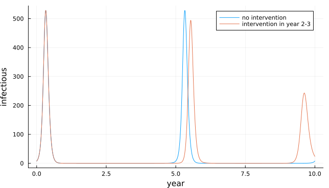

```julia
plot(years, sol[I]; label = "no intervention", xlabel = "year", ylabel = "infectious")
plot!(years, sol_int[I]; label = "intervention in year 2-3")
```

## Evaluating along any solution

The same `R_t` trajectory can be computed from a solution of the original system, without the observed variable, by evaluating the numeric next-generation matrix at each saved state (this also works when no closed form exists):

```julia
ngm = next_generation_matrix(sir, [I]; equilibrium = Dict(), autonomous = false)
sol0 = solve(ODEProblem(sir, [attractor; p], (0.0, 10year)), Tsit5(); saveat = year / 4)
Rt0 = effective_reproduction_number(ngm, sol0)
maximum(abs, Rt0 .- sol(sol0.t; idxs = Rtvar).u)
```

```
1.4914776940377905e-5
```